# Session 1

A very quick introduction to research on human nature (PY0552)

Thomas V. Pollet (thomas.pollet@northumbria.ac.uk)

2020-01-31

# Introduction.

- Who am I? Who are you?

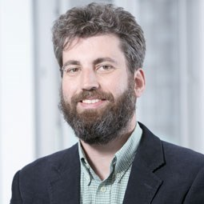

Me

- Why did you pick this course? What do you want to get out of this course?
- Human Nature –> Evolutionary Psychology? What is it? What do you know about it?
- Seminar format. Blackboard. Assessment.
- Embodied cognition (Dr. Larry Taylor).

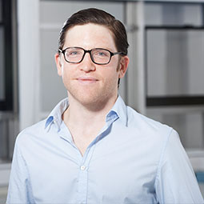

Larry

# Set-up.

# Evolutionary approach.

- Evolutionary Psychology / Human Behavioral Ecology / Cultural evolution.

  Cosmides & Tooby (1997)

  Cronk (1991)

  Boyd & Richerson (1985)
- Different views reviewed in.

  Smith et al. (2001);Sear et al. (2007);Laland & Brown (2011)

# Terminology

- Adaptation.
- Vestige.

  Examples in [your body](https://bigthink.com/surprising-science/your-bodys-full-of-stuff-you-no-longer-need)
- Exaptation.
- Spandrel.

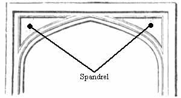

Spandrel

- ‘Selfish gene’.

  An explanation by [Richard Dawkins](https://www.youtube.com/watch?v=j9p2F2oa0_k)
- Natural selection vs. sexual selection.
- ‘Mismatch’.
- ‘Blank slatism’

[figure not shown]

Book by Pinker

- Massive modularity

[figure not shown]

A model for the mind

- ‘Just so stories’

[figure not shown]

Just so stories

- Evironment of Evolutionary Adaptedness

  Foley (1995)
- “Stone age brain in the fast lane.”

# Tinbergen’s 4 why’s.

Nobel Prize winner Niko Tinbergen:

Tinbergen (1963);Bateson & Laland (2013)

- Mechanism
- Ontogeny
- Phylogeny
- Function

# Controversies

- Nature vs. Nurture.
- Naturalistic fallacy.
- Genetic determinism.
- Human uniqueness.
- Bad science… .
- “Just so story”
- “WEIRD” populations.

  Henrich et al. (2010)

# References

Bateson, P., & Laland, K. N. (2013). Tinbergen’s four questions: an appreciation and an update. *Trends in Ecology & Evolution*, *28*(12), 712–718. https://doi.org/10.1016/j.tree.2013.09.013

Boyd, R., & Richerson, P. J. (1985). *Culture and the evolutionary process*. University of Chicago Press.

Cosmides, L., & Tooby, J. (1997). *Evolutionary psychology: A primer*. http://www.cep.ucsb.edu/primer.html

Cronk, L. (1991). Human Behavioral Ecology. *Annual Review of Anthropology*, *20*(1), 25–53. https://doi.org/10.1146/annurev.an.20.100191.000325

Foley, R. (1995). The adaptive legacy of human evolution: A search for the environment of evolutionary adaptedness. *Evolutionary Anthropology: Issues, News, and Reviews*, *4*(6), 194–203. https://doi.org/10.1002/evan.1360040603

Henrich, J., Heine, S. J., & Norenzayan, A. (2010). The weirdest people in the world. *Behavioral and Brain Sciences*, *33*(2-3), 61–83. https://doi.org/10.1017/S0140525X0999152X

Laland, K. N., & Brown, G. (2011). *Sense and nonsense: Evolutionary perspectives on human behaviour* (2nd ed.). Oxford University Press.

Sear, R., Lawson, D. W., & Dickins, T. E. (2007). Synthesis in the human evolutionary behavioural sciences. *Journal of Evolutionary Psychology*, *5*(1), 3–28. https://doi.org/10.1556/JEP.2007.1019

Smith, E. A., Mulder, M. B., & Hill, K. (2001). Controversies in the evolutionary social sciences: A guide for the perplexed. *Trends in Ecology & Evolution*, *16*(3), 128–135. https://doi.org/10.1016/S0169-5347(00)02077-2

Tinbergen, N. (1963). On aims and methods of ethology. *Zeitschrift Für Tierpsychologie*, *20*(4), 410–433. https://doi.org/10.1111/j.1439-0310.1963.tb01161.x